# Project: Investigate a Dataset (No showup appointments)

- Introduction
- Data Wrangling
- Exploratory Data Analysis
- Conclusions

## Introduction

### Questons to be explored :

> **Is** there a relationship between the *gender* and the *noshowup* variable ? **Is** there a relationship between the *age* and the *noshowup* variable ? **What** is the best *hospital* which patients have the committment to attend the showup ? **What** are the most *disease* whose people have the committment to attend the showup ? **What** is the relation between *age* and different *diseases* ?

```python
# Use this cell to set up import statements for all of the packages that you
#   plan to use.

# Remember to include a 'magic word' so that your visualizations are plotted
#   inline with the notebook. See this page for more:
#   http://ipython.readthedocs.io/en/stable/interactive/magics.html
import pandas as pd
import numpy as np
from datetime import datetime
import matplotlib.pyplot as plt
% matplotlib inline
```

## Data Wrangling

> **Tip**: In this section of the report, you will load in the data, check for cleanliness, and then trim and clean your dataset for analysis. Make sure that you document your steps carefully and justify your cleaning decisions.

### General Properties

```python
# Load your data and print out a few lines. Perform operations to inspect data
#   types and look for instances of missing or possibly errant data.
df = pd.read_csv('noshowappointments-kagglev2-may-2016.csv')  # upload data
df.head()                                                    # take a first look at data
```

|  | PatientId | AppointmentID | Gender | ScheduledDay | AppointmentDay | Age | Neighbourhood | Scholarship | Hipertension | Diabetes | Alcoholism | Handcap | SMS_received | No-show |
| --- | --- | --- | --- | --- | --- | --- | --- | --- | --- | --- | --- | --- | --- | --- |
| 0 | 2.987250e+13 | 5642903 | F | 2016-04-29T18:38:08Z | 2016-04-29T00:00:00Z | 62 | JARDIM DA PENHA | 0 | 1 | 0 | 0 | 0 | 0 | No |
| 1 | 5.589980e+14 | 5642503 | M | 2016-04-29T16:08:27Z | 2016-04-29T00:00:00Z | 56 | JARDIM DA PENHA | 0 | 0 | 0 | 0 | 0 | 0 | No |
| 2 | 4.262960e+12 | 5642549 | F | 2016-04-29T16:19:04Z | 2016-04-29T00:00:00Z | 62 | MATA DA PRAIA | 0 | 0 | 0 | 0 | 0 | 0 | No |
| 3 | 8.679510e+11 | 5642828 | F | 2016-04-29T17:29:31Z | 2016-04-29T00:00:00Z | 8 | PONTAL DE CAMBURI | 0 | 0 | 0 | 0 | 0 | 0 | No |
| 4 | 8.841190e+12 | 5642494 | F | 2016-04-29T16:07:23Z | 2016-04-29T00:00:00Z | 56 | JARDIM DA PENHA | 0 | 1 | 1 | 0 | 0 | 0 | No |

First, we want to have some basic information about the dataframe.

```python
df.shape
```

```
(110527, 14)
```

We have data for 110527 patients, but how many of them have null cells

```python
df.info()
```

```
<class 'pandas.core.frame.DataFrame'>
RangeIndex: 110527 entries, 0 to 110526
Data columns (total 14 columns):
PatientId         110527 non-null float64
AppointmentID     110527 non-null int64
Gender            110527 non-null object
ScheduledDay      110527 non-null object
AppointmentDay    110527 non-null object
Age               110527 non-null int64
Neighbourhood     110527 non-null object
Scholarship       110527 non-null int64
Hipertension      110527 non-null int64
Diabetes          110527 non-null int64
Alcoholism        110527 non-null int64
Handcap           110527 non-null int64
SMS_received      110527 non-null int64
No-show           110527 non-null object
dtypes: float64(1), int64(8), object(5)
memory usage: 11.8+ MB
```

So now we do not have any null cells in our dataframe. All have 110527 non-null cells. We do not need to do any cleaning for the dataframe for the null values. Next, we check for unique values.

```python
df.nunique()
```

```
PatientId          61744
AppointmentID     110527
Gender                 2
ScheduledDay      103549
AppointmentDay        27
Age                  104
Neighbourhood         81
Scholarship            2
Hipertension           2
Diabetes               2
Alcoholism             2
Handcap                5
SMS_received           2
No-show                2
dtype: int64
```

```python
df['Handcap'].unique()
```

```
array([0, 1, 2, 3, 4])
```

```python
df.describe()
```

|  | PatientId | AppointmentID | Age | Scholarship | Hipertension | Diabetes | Alcoholism | Handcap | SMS_received |
| --- | --- | --- | --- | --- | --- | --- | --- | --- | --- |
| count | 1.105270e+05 | 1.105270e+05 | 110527.000000 | 110527.000000 | 110527.000000 | 110527.000000 | 110527.000000 | 110527.000000 | 110527.000000 |
| mean | 1.474963e+14 | 5.675305e+06 | 37.088874 | 0.098266 | 0.197246 | 0.071865 | 0.030400 | 0.022248 | 0.321026 |
| std | 2.560949e+14 | 7.129575e+04 | 23.110205 | 0.297675 | 0.397921 | 0.258265 | 0.171686 | 0.161543 | 0.466873 |
| min | 3.920000e+04 | 5.030230e+06 | -1.000000 | 0.000000 | 0.000000 | 0.000000 | 0.000000 | 0.000000 | 0.000000 |
| 25% | 4.172615e+12 | 5.640286e+06 | 18.000000 | 0.000000 | 0.000000 | 0.000000 | 0.000000 | 0.000000 | 0.000000 |
| 50% | 3.173180e+13 | 5.680573e+06 | 37.000000 | 0.000000 | 0.000000 | 0.000000 | 0.000000 | 0.000000 | 0.000000 |
| 75% | 9.439170e+13 | 5.725524e+06 | 55.000000 | 0.000000 | 0.000000 | 0.000000 | 0.000000 | 0.000000 | 1.000000 |
| max | 9.999820e+14 | 5.790484e+06 | 115.000000 | 1.000000 | 1.000000 | 1.000000 | 1.000000 | 4.000000 | 1.000000 |

In the next two cells we will have a look at the types of esch column data so we can take the right decisions for data cleaning

```python
df.dtypes
```

```
PatientId         float64
AppointmentID       int64
Gender             object
ScheduledDay       object
AppointmentDay     object
Age                 int64
Neighbourhood      object
Scholarship         int64
Hipertension        int64
Diabetes            int64
Alcoholism          int64
Handcap             int64
SMS_received        int64
No-show            object
dtype: object
```

```python
type(df['ScheduledDay'][0])
```

```
str
```

Now, it is time to check for duplicates and clean up our dataset from them if there were any of them.

```python
df[df.duplicated()].shape[0]
```

```
0
```

From the previous analysis, our dataframe seems to be clean and does not need so much work for data cleaning.Only the two columns ScheduledDay and AppointmentDay may be reajusted so they contain date only.The time part can be separated in a separate column. Also the age column has min value of -1 . This is illogic. We can replace them to be 0 (means the patient is a baby) or we can delete them. I will choose the second choice for deleting them because I do not know for what this -1 stands exactly.

> **Tip**: You should *not* perform too many operations in each cell. Create cells freely to explore your data. One option that you can take with this project is to do a lot of explorations in an initial notebook. These don't have to be organized, but make sure you use enough comments to understand the purpose of each code cell. Then, after you're done with your analysis, create a duplicate notebook where you will trim the excess and organize your steps so that you have a flowing, cohesive report.

> **Tip**: Make sure that you keep your reader informed on the steps that you are taking in your investigation. Follow every code cell, or every set of related code cells, with a markdown cell to describe to the reader what was found in the preceding cell(s). Try to make it so that the reader can then understand what they will be seeing in the following cell(s).

### Data Cleaning (Cleaning age and dates)

```python
# After discussing the structure of the data and any problems that need to be
#   cleaned, perform those cleaning steps in the second part of this section.
sum(df['Age'] < 0)
```

```
1
```

```python
df_illogic_age = df[df['Age'] <0]
df_illogic_age
```

|  | PatientId | AppointmentID | Gender | ScheduledDay | AppointmentDay | Age | Neighbourhood | Scholarship | Hipertension | Diabetes | Alcoholism | Handcap | SMS_received | No-show |
| --- | --- | --- | --- | --- | --- | --- | --- | --- | --- | --- | --- | --- | --- | --- |
| 99832 | 4.659430e+14 | 5775010 | F | 2016-06-06T08:58:13Z | 2016-06-06T00:00:00Z | -1 | ROMÃO | 0 | 0 | 0 | 0 | 0 | 0 | No |

```python
df = df.drop(99832)
```

Now, Clean the two columns SceduledDay and AppointmentDay to be both as iso date format

```python
list1=[]
list2 = pd.Series.tolist(df['ScheduledDay'])    # convert dataseries or column to list
for i in list2:
    list1.append(datetime.strptime(i,"%Y-%m-%dT%H:%M:%SZ")) # iterate over the list to convert from string to date
df['ScheduledDate'] = pd.Series(list1)
```

```python
# the same codebut applied for the column of appointment day
list3=[]
list4 = pd.Series.tolist(df['AppointmentDay'])
for i in list4:
    list3.append(datetime.strptime(i,"%Y-%m-%dT%H:%M:%SZ"))

df['AppointmentDate'] = pd.Series(list3)
```

Now we can remove the two columns of appointment day and sheduled day and construct our modified dataframe

```python
# drop unnecessary columns
df_mod = df.drop(['ScheduledDay','AppointmentDay'],axis = 1)
```

We can create a new column to identify the age stage of the patients based on their ages

```python
# use pandas.cut function
age_edges = [0,12,22,50,115]
age_labels = ['child','adult','youth','old']
df_mod['Age_Stage'] = pd.cut(df['Age'],age_edges,labels = age_labels)
df_mod.head()
```

|  | PatientId | AppointmentID | Gender | Age | Neighbourhood | Scholarship | Hipertension | Diabetes | Alcoholism | Handcap | SMS_received | No-show | ScheduledDate | AppointmentDate | Age_Stage |
| --- | --- | --- | --- | --- | --- | --- | --- | --- | --- | --- | --- | --- | --- | --- | --- |
| 0 | 2.987250e+13 | 5642903 | F | 62 | JARDIM DA PENHA | 0 | 1 | 0 | 0 | 0 | 0 | No | 2016-04-29 18:38:08 | 2016-04-29 | old |
| 1 | 5.589980e+14 | 5642503 | M | 56 | JARDIM DA PENHA | 0 | 0 | 0 | 0 | 0 | 0 | No | 2016-04-29 16:08:27 | 2016-04-29 | old |
| 2 | 4.262960e+12 | 5642549 | F | 62 | MATA DA PRAIA | 0 | 0 | 0 | 0 | 0 | 0 | No | 2016-04-29 16:19:04 | 2016-04-29 | old |
| 3 | 8.679510e+11 | 5642828 | F | 8 | PONTAL DE CAMBURI | 0 | 0 | 0 | 0 | 0 | 0 | No | 2016-04-29 17:29:31 | 2016-04-29 | child |
| 4 | 8.841190e+12 | 5642494 | F | 56 | JARDIM DA PENHA | 0 | 1 | 1 | 0 | 0 | 0 | No | 2016-04-29 16:07:23 | 2016-04-29 | old |

## Exploratory Data Analysis

> **Tip**: Now that you've trimmed and cleaned your data, you're ready to move on to exploration. Compute statistics and create visualizations with the goal of addressing the research questions that you posed in the Introduction section. It is recommended that you be systematic with your approach. Look at one variable at a time, and then follow it up by looking at relationships between variables.

### Research Question 1 (What is the relation between gender of patient and noshow variable ?)

We assume first that males are more committed to their scheduled dates than females becuase maybe they can move freely!

```python
# create two dataframes one for males and the other for females
df_male = df_mod[df_mod['Gender'] == 'M']
df_female = df_mod[df_mod['Gender'] == 'F']
df_male.head()
```

|  | PatientId | AppointmentID | Gender | Age | Neighbourhood | Scholarship | Hipertension | Diabetes | Alcoholism | Handcap | SMS_received | No-show | ScheduledDate | AppointmentDate | Age_Stage |
| --- | --- | --- | --- | --- | --- | --- | --- | --- | --- | --- | --- | --- | --- | --- | --- |
| 1 | 5.589980e+14 | 5642503 | M | 56 | JARDIM DA PENHA | 0 | 0 | 0 | 0 | 0 | 0 | No | 2016-04-29 16:08:27 | 2016-04-29 | old |
| 11 | 7.542950e+12 | 5620163 | M | 29 | NOVA PALESTINA | 0 | 0 | 0 | 0 | 0 | 1 | Yes | 2016-04-26 08:44:12 | 2016-04-29 | youth |
| 13 | 9.113950e+14 | 5636249 | M | 28 | NOVA PALESTINA | 0 | 0 | 0 | 0 | 0 | 0 | No | 2016-04-28 14:52:07 | 2016-04-29 | youth |
| 16 | 8.457440e+13 | 5633121 | M | 50 | NOVA PALESTINA | 0 | 0 | 0 | 0 | 0 | 0 | No | 2016-04-28 08:51:47 | 2016-04-29 | youth |
| 22 | 8.632300e+14 | 5616091 | M | 13 | CONQUISTA | 0 | 0 | 0 | 0 | 0 | 1 | Yes | 2016-04-25 13:29:16 | 2016-04-29 | adult |

We will count how many patients in the two dataframes but grouped by according to the No-show variable

```python
males_showup = df_male.groupby('No-show')['PatientId'].count()[0]
males_noshowup = df_male.groupby('No-show')['PatientId'].count()[1]
```

```python
females_showup = df_female.groupby('No-show')['PatientId'].count()[0]
females_noshowup = df_female.groupby('No-show')['PatientId'].count()[1]
```

To make the comparison fair we should compare the percentage of the No-show variable for males and females

```python
pro_males_attended_showup = df_male.groupby('No-show')['PatientId'].count()[0] / df_male.shape[0]
pro_females_attended_showup = df_female.groupby('No-show')['PatientId'].count()[0] / df_female.shape[0]

pro_males_attended_showup ,pro_females_attended_showup
```

```
(0.80032052110528085, 0.79685129247344755)
```

The percentage of males who attended the showup is equal to females.

Making a bar plot to visualize this data.

[figure not shown]

```python
n = 2
ind = np.arange(n)
width=0.4

attended_showup  = (males_showup ,females_showup)
not_attended_showup = (males_noshowup,females_noshowup )

p1 =plt.bar(ind ,attended_showup, width)
p2 =plt.bar(ind, not_attended_showup , width)

plt.ylabel('number of patients')
plt.title('Showup Statistics according to Gender')
plt.xticks(ind, ('males','females'))

plt.legend((p1[0], p2[0]), ( 'Males','Females'))
```

The final conclusion is that there is no relation between the gender and the showup variable because the percentage is almost the same. The visualization is tricky.The females bar is higher because the total number of females is higher.

### Research Question 2 (What is the relation between age and showup variable ? )

We can expect that people whose ages are between 20 and 50 have less showup rates than others because they are busier and their health is better

```python
df_mod.groupby('Age_Stage')['PatientId'].count()
child_count = df_mod.groupby('Age_Stage')['PatientId'].count()[0]
adult_count = df_mod.groupby('Age_Stage')['PatientId'].count()[1]
youth_count = df_mod.groupby('Age_Stage')['PatientId'].count()[2]
old_count  = df_mod.groupby('Age_Stage')['PatientId'].count()[3]
```

```python
# group by according to age stage and noshow
df_mod.groupby(['Age_Stage','No-show'])['PatientId'].count()
child_showup = df_mod.groupby(['Age_Stage','No-show'])['PatientId'].count()[0]
adult_showup = df_mod.groupby(['Age_Stage','No-show'])['PatientId'].count()[2]
youth_showup = df_mod.groupby(['Age_Stage','No-show'])['PatientId'].count()[4]
old_showup = df_mod.groupby(['Age_Stage','No-show'])['PatientId'].count()[6]
```

```python
# calculating the proportions
child_pro = child_showup /child_count
adult_pro = adult_showup / adult_count
youth_pro = youth_showup/ youth_count
old_pro = old_showup / old_count
child_pro,adult_pro,youth_pro,old_pro
```

```
(0.79036406241069901,
 0.74376832844574781,
 0.7825710539985653,
 0.83832538181407557)
```

As expected above, The old men have the highest showup percentage,then chidren and adults are the most careless

It is time to visualize this data. First graph to show how many are the patients of each age stage. **Second Graph is to show how many attended of the total number grouped by age stage.

[output not shown]

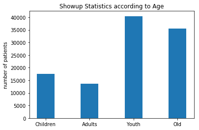

```python
n = 4
ind = np.arange(n)
width=0.4
age_stage_data = df_mod.groupby('Age_Stage')['PatientId'].count()
plt.bar(ind ,age_stage_data, width)

plt.ylabel('number of patients')
plt.title('Showup Statistics according to Age')
plt.xticks(ind, ('Children','Adults','Youth','Old'))
```

[figure not shown]

```python
n = 4
ind = np.arange(n)
width=0.4

attended_showup  = ( child_showup,adult_showup,youth_showup,old_showup)
total_no = (child_count,adult_count,youth_count, old_count)

p1 =plt.bar(ind ,total_no, width)
p2 =plt.bar(ind, attended_showup , width)

plt.ylabel('number of patients')
plt.title('Showup Statistics according to Age Stage Graph no. 2 ')
plt.xticks(ind, ('Children','Adults','Youth','Old'))

plt.legend((p1[0], p2[0]), ( 'Showup yes','Total number'))
```

Because the graph is a little bit tricky because the number of patients at different ages is different.We can plot the graph in a nicer way by plotting the proportins rather than the actual number of patients.

[figure not shown]

```python
n = 4
ind = np.arange(n)
width=0.4

attended_showup  = ( child_pro,adult_pro,youth_pro,old_pro)
total_no = (1,1,1,1)

p1 =plt.bar(ind ,total_no, width)
p2 =plt.bar(ind, attended_showup , width)

plt.ylabel('number of patients')
plt.title('Showup Statistics according to Age Stage Graph no. 2 ')
plt.xticks(ind, ('Children','Adults','Youth','Old'))

plt.legend((p1[0], p2[0]), ( 'Showup yes','Total number'))
```

The Final conclusion is that Old are more than others to attend the showup while adults are the least . youth are the most people who are enrolled in the database.

### Research Question 3 (what is the relation between the hospital and the showup variable ?)

We will group by the hospital location and the No-show variable, then we will calculate the ratio of attendance for each hospital

```python
# grouping by Neighbourhood and No-show
ratio_of_attendance=[]  # List to append ratios to
a =df_mod.groupby(['Neighbourhood','No-show'])['PatientId'].count()
# calculating the ratio of show up by deviding no by yes and no for the same hospital
for i in range(0,len(a),2):
    ratio_of_attendance .append((a[i] / (a[i+1]+a[i]) ))
```

The data in ( a ) is sorted in alphapetical order ,so we need to sort the hospital location strings in alphabetical order also so we construct a dataframe with two columns :*The hospital location names and ratio of attendence for each hospital*

```python
hospital_location = df_mod['Neighbourhood'].sort_values()
hospital_location = hospital_location.drop_duplicates() # drop duplicated names
hospital_location = pd.Series.tolist(hospital_location) # convert to series

# to adjust the length of the two lists
ratio_of_attendance.append(0)
```

[output not shown]

Now time to construct our dataframe.

```python
data =[]
for i in range(80):
    data.append([hospital_location[i],ratio_of_attendance[i]])
# construct dataframe
df_hospital = pd.DataFrame(data, columns = ['HospitalLocation', 'AttendanceRatio'])
df_hospital.head()
```

|  | HospitalLocation | AttendanceRatio |
| --- | --- | --- |
| 0 | AEROPORTO | 0.875000 |
| 1 | ANDORINHAS | 0.769673 |
| 2 | ANTÔNIO HONÓRIO | 0.815498 |
| 3 | ARIOVALDO FAVALESSA | 0.780142 |
| 4 | BARRO VERMELHO | 0.784870 |

It is time to make use of our dataframe. Viualization will not be very useful because we have 80 hospitals. But we can know which hospitals have high showup rates and others with low showup rates

```python
df_hospital.describe()
```

|  | AttendanceRatio |
| --- | --- |
| count | 80.000000 |
| mean | 0.691111 |
| std | 0.245722 |
| min | 0.002334 |
| 25% | 0.763919 |
| 50% | 0.793691 |
| 75% | 0.814451 |
| max | 0.997519 |

```python
df_hospital_showup_high = df_hospital[df_hospital['AttendanceRatio'] > 0.9]
df_hospital_showup_high
```

|  | HospitalLocation | AttendanceRatio |
| --- | --- | --- |
| 31 | ILHA DO BOI | 0.914286 |
| 50 | NOVA PALESTINA | 0.997519 |

```python
df_hospital_showup_low = df_hospital[df_hospital['AttendanceRatio'] < 0.1]
df_hospital_showup_low
```

|  | HospitalLocation | AttendanceRatio |
| --- | --- | --- |
| 34 | ILHAS OCEÂNICAS DE TRINDADE | 0.002334 |
| 35 | INHANGUETÁ | 0.072324 |
| 37 | JABOUR | 0.067283 |
| 42 | JUCUTUQUARA | 0.028184 |
| 47 | MORADA DE CAMBURI | 0.048048 |
| 49 | NAZARETH | 0.015336 |

ILHA DO BOI and NOVA PALESTINA have high showup rates.NOVA PALESTINA has showup rate of 0.997!! While ILHAS OCEÂNICAS DE TRINDADE has showup rate of 0.002334 .

## Question 4 : Waht is the relation between the variable of SMS_received and No-show ?

```python
# grouping by SMS_received and No-show variable
df_mod.groupby(['SMS_received','No-show'])['PatientId'].count()
```

```
SMS_received  No-show
0             No         62509
              Yes        12535
1             No         25698
              Yes         9784
Name: PatientId, dtype: int64
```

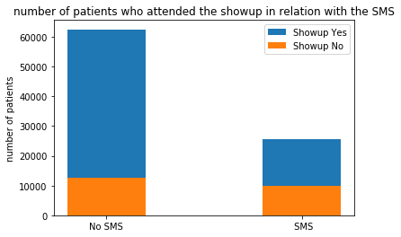

```python
n = 2
ind = np.arange(n)
width=0.4

showup_data  = (62509 , 25698)
no_showup_data = (12535 ,9784)

p1 =plt.bar(ind ,showup_data, width)
p2 =plt.bar(ind, no_showup_data , width)
figsize = (50,50)
plt.ylabel('number of patients')
plt.title('number of patients who attended the showup in relation with the SMS')
plt.xticks(ind, ( 'No SMS', ' SMS'))
#plt.yticks(np.arange(0, 81, 10))
plt.legend((p1[0], p2[0]), ( 'Showup Yes','Showup No'))
```

## Is there a relation between the handcap degree and the showup variable ?

```python
# Grouping by
a = df_mod.groupby(['Handcap','No-show'])['PatientId'].count()
a
```

```
Handcap  No-show
0        No         86373
         Yes        21912
1        No          1676
         Yes          366
2        No           146
         Yes           37
3        No            10
         Yes            3
4        No             2
         Yes            1
Name: PatientId, dtype: int64
```

A graph can show us the relation easily

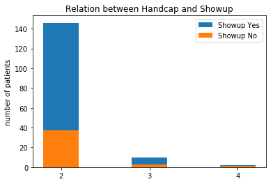

```python
n = 3
ind = np.arange(n)
width=0.4
showup_handcap = (a[2][0],a[3][0],a[4][0])
no_showup_handcap = (a[2][1],a[3][1],a[4][1])
p1 =plt.bar(ind ,showup_handcap, width)
p2 =plt.bar(ind, no_showup_handcap, width)


plt.ylabel('number of patients')
plt.title('Relation between Handcap and Showup')
plt.xticks(ind, ( '2','3','4'))

plt.legend((p1[0], p2[0]), ( 'Showup Yes','Showup No'))
```

The reults here may not be fair because the number of persons who have higher degrees of handcap is too less than others. For that reason I have removed the first data point for person whose handcap degree = 0 and 1.

## Submitting your Project

> Before you submit your project, you need to create a .html or .pdf version of this notebook in the workspace here. To do that, run the code cell below. If it worked correctly, you should get a return code of 0, and you should see the generated .html file in the workspace directory (click on the orange Jupyter icon in the upper left).

> Alternatively, you can download this report as .html via the **File** > **Download as** submenu, and then manually upload it into the workspace directory by clicking on the orange Jupyter icon in the upper left, then using the Upload button.

> Once you've done this, you can submit your project by clicking on the "Submit Project" button in the lower right here. This will create and submit a zip file with this .ipynb doc and the .html or .pdf version you created. Congratulations!

```python
from subprocess import call
call(['python', '-m', 'nbconvert', 'Investigate_a_Dataset.ipynb'])
```

```
0
```